# Analisi sulle vendite dei videogiochi

18/01/2022

## Introduzione

I videogiochi sono stati prodotti per la prima volta negli anni ’50, ma non hanno raggiunto una grande popolarità fino agli anni ’80, quando sono stati introdotti al grande pubblico i videogiochi arcade e le prime console domestiche.

Da quel momento in poi i videogiochi sono diventati una forma di intrattenimento e una parte della cultura moderna nella maggior parte del mondo.

Oggi una persona su tre gioca ai videogiochi.

## Dataset

Il Dataset che ho usato si chiama *vgsales-2019* ed è reperibile a questo indirizzo [VgSales](https://www.kaggle.com/janoslaszlo/video-games-sales-2019)

Comprende oltre trentamila videogiochi e per ognuno di essi specifica: nome, vendite, genere, console e publisher.

Inoltre ho usato anche il Dataset [MetacriticVG](https://www.kaggle.com/brunovr/metacritic-videogames-data) dove sono contenuti i voti assegnati ad ogni videogioco dalla rivista specializzata [Metacritic](https://www.metacritic.com/).

## Produzione di videogiochi durante gli anni

Videogiochi rilasciati dagli anni ottanti fino al 2019

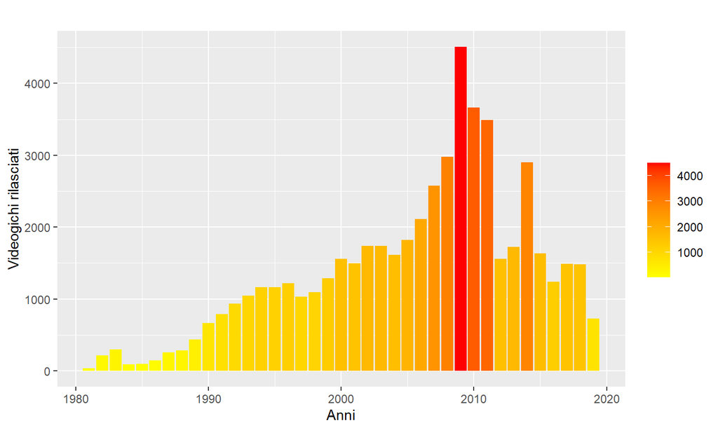

## Quali sono le console più importanti?

Videogiochi venduti per ogni tipo di console:

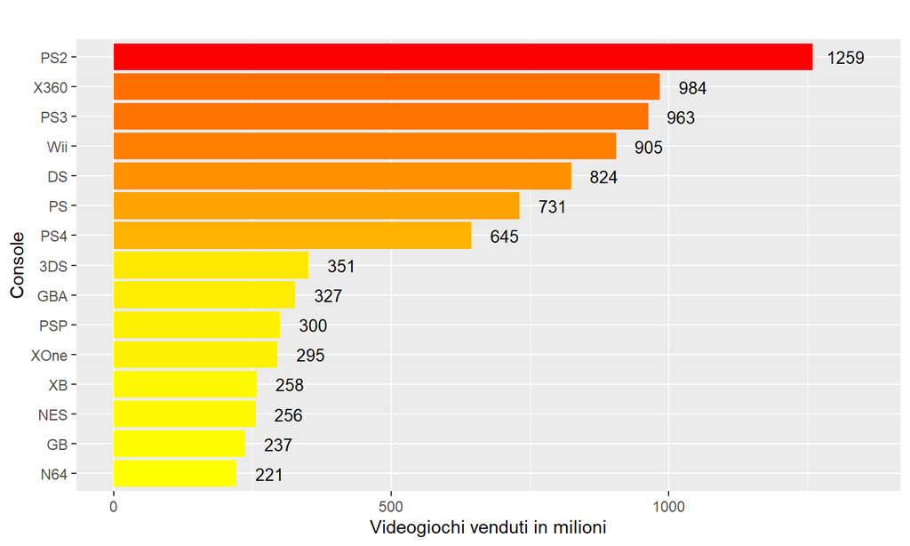

## Vendite durante gli anni dei maggiori distributori di console

[figure not shown]

## Quali sono i publisher più importanti?

Videogiochi sviluppati dai migliori Publisher:

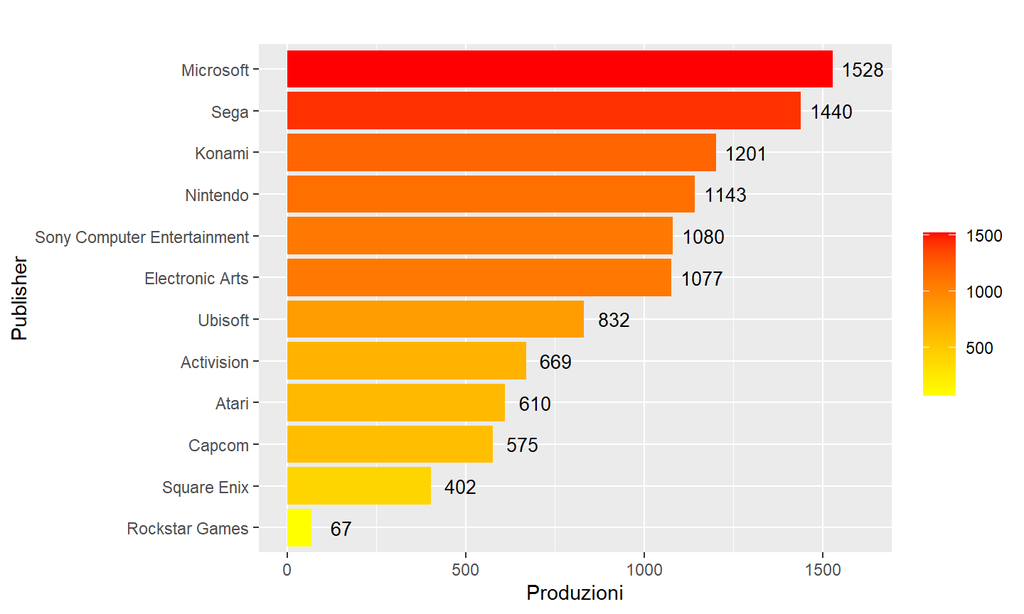

## Quali sono i publisher più importanti?

Vendite per i migliori Publisher:

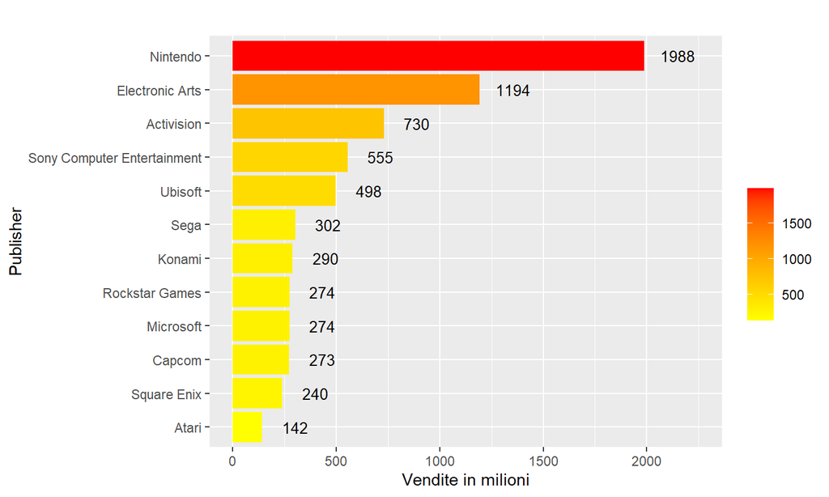

## Quali sono i generi più venduti?

Vendite per ogni genere:

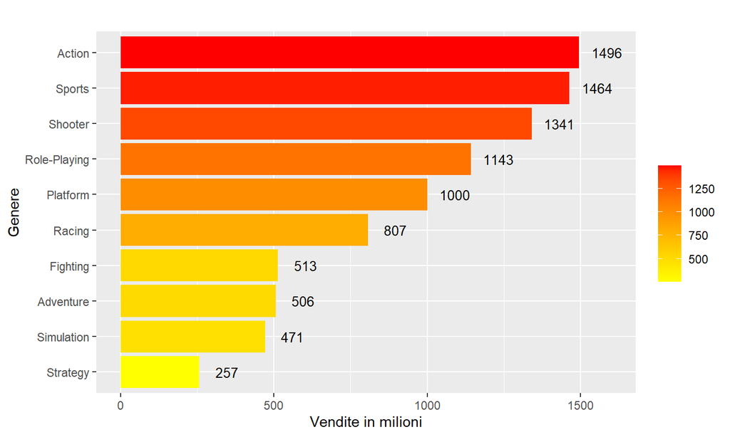

## Relazione fra generi e publisher

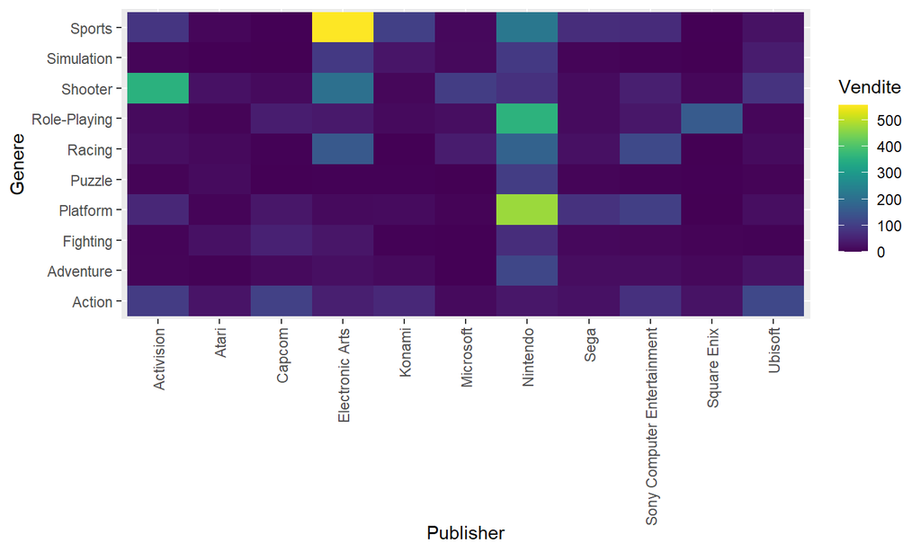

|  | Name | CasaDISviluppo | Genre | Total_Sales |
| --- | --- | --- | --- | --- |
| 1 | Call of Duty: Black Ops 3 | Activision | Shooter | 15.09 |
| 2 | Call of Duty: Modern Warfare 3 | Activision | Shooter | 14.82 |
| 3 | Call of Duty: Black Ops | Activision | Shooter | 14.74 |
| 4 | Call of Duty: Black Ops II | Activision | Shooter | 13.86 |
| 5 | Call of Duty: Black Ops II | Activision | Shooter | 13.8 |
| 6 | Call of Duty: Modern Warfare 2 | Activision | Shooter | 13.53 |
| 7 | Call of Duty: WWII | Activision | Shooter | 13.4 |
| 8 | Call of Duty: Modern Warfare 3 | Activision | Shooter | 13.35 |
| 9 | Call of Duty: Black Ops | Activision | Shooter | 12.67 |
| 10 | Call of Duty: Modern Warfare 2 | Activision | Shooter | 10.61 |

[output cut: 5 more lines]

|  | Name | CasaDISviluppo | Genre | Total_Sales |
| --- | --- | --- | --- | --- |
| 1 | FIFA 18 | Electronic Arts | Sports | 11.8 |
| 2 | FIFA 17 | Electronic Arts | Sports | 10.94 |
| 3 | FIFA 19 | Electronic Arts | Sports | 9.15 |
| 4 | FIFA 16 | Electronic Arts | Sports | 8.22 |
| 5 | Star Wars Battlefront (2015) | Electronic Arts | Shooter | 8.03 |
| 6 | FIFA 13 | Electronic Arts | Sports | 8.01 |
| 7 | The Sims 3 | Electronic Arts | Simulation | 7.96 |
| 8 | Battlefield 3 | Electronic Arts | Shooter | 7.35 |
| 9 | Battlefield 1 | Electronic Arts | Shooter | 7.26 |
| 10 | Battlefield 3 | Electronic Arts | Shooter | 7.21 |

[output cut: 5 more lines]

## Generi nel mondo

Percentuali di vendite dei migliori generi nel mondo:

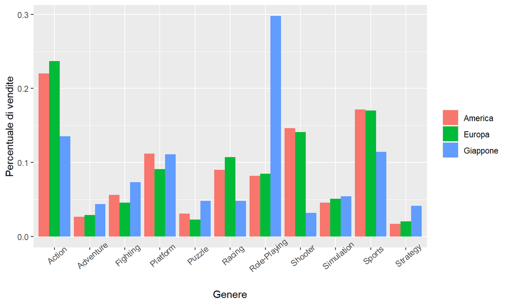

## Quali sono i giochi più venduti?

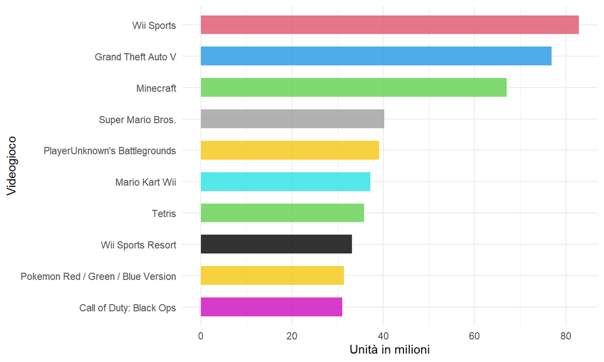

## I videogiochi più venduti sono effettivamenti i più validi secondo Metacritic?

## NO!

Correlazione tra le vendite e il punteggio voti assegnato dalla rivista specializzata Metacritic:

```
##
##  Pearson's product-moment correlation
##
## data:  Cor$score and Cor$Sales
## t = 8.8596, df = 1616, p-value < 2.2e-16
## alternative hypothesis: true correlation is not equal to 0
## 95 percent confidence interval:
##  0.1682571 0.2612173
## sample estimates:
##       cor
## 0.2152247
```

## Tabella di confronto Vendite/Voti

|  | name | score | Sales |
| --- | --- | --- | --- |
| 1 | The Legend of Zelda: Ocarina of Time | 99 | 7.6 |
| 2 | Tony Hawk's Pro Skater 2 | 98 | 6.62 |
| 3 | Grand Theft Auto IV | 98 | 22.53 |
| 4 | Super Mario Galaxy | 97 | 12.78 |
| 5 | Super Mario Galaxy 2 | 97 | 7.41 |
| 6 | Red Dead Redemption 2 | 97 | 19.71 |
| 7 | Grand Theft Auto V | 97 | 76.89 |
| 8 | The Legend of Zelda: Breath of the Wild | 97 | 13.29 |
| 9 | Tony Hawk's Pro Skater 3 | 97 | 8.05 |
| 10 | Perfect Dark | 97 | 2.52 |

[output cut: 1608 more lines]